# Lipid drug-target genes & dementia risk — a two-sample MR reproduction

GLGC (exposure) × FinnGen (outcome), with an OpenGWAS extension

Workshop tutorial

2026-09-02

> **What this is.** A workshop reproduction of the *two-sample Mendelian randomization (2SMR) arm* of Nordestgaard et al., *Alzheimer’s & Dementia* 2025 — do genetically-proxied lower non-HDL cholesterol, via six lipid drug-target genes, reduce dementia risk?

> **What this is not.** Not the paper’s exact numbers, and not its one-sample / Cox arms. We use only the two **no-request public** datasets (GLGC lipids = exposure; FinnGen dementia and **ischemic heart disease (IHD)** = outcome). See plan.md and research.md.

# 1 The paper’s headline result (not ours)

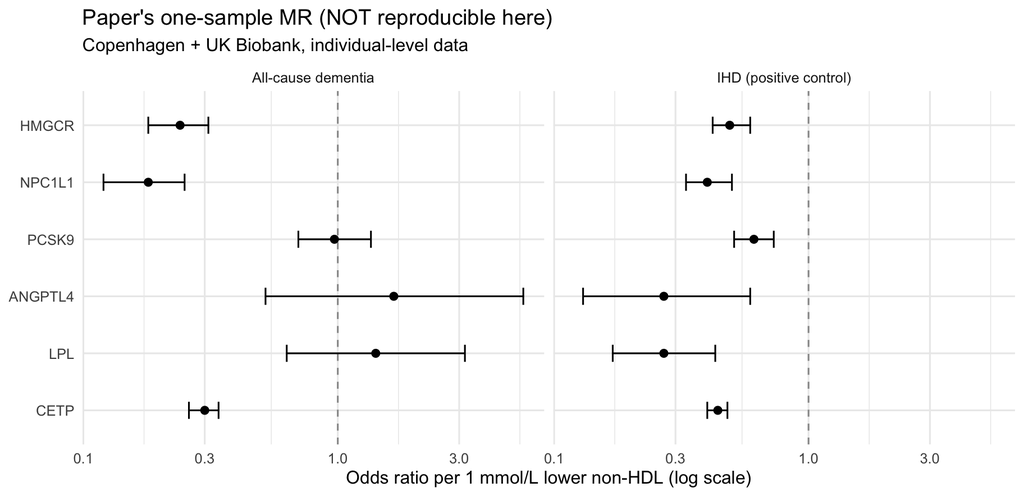

The paper’s ONE-SAMPLE MR results (Copenhagen + UK Biobank individual-level data), per 1 mmol/L lower non-HDL. We could NOT reproduce these — shown for context. NOTE the unit differs from our per-SD two-sample estimates, so magnitudes are not directly comparable; compare directions only.

```r
paper1 <- rbindlist(list(
  data.table(outcome="dementia_all", gene=gene_order,
    or=c(0.24,0.18,0.97,1.66,1.41,0.30), lo=c(0.18,0.12,0.70,0.52,0.63,0.26), hi=c(0.31,0.25,1.35,5.36,3.16,0.34)),
  data.table(outcome="ihd", gene=gene_order,
    or=c(0.49,0.40,0.61,0.27,0.27,0.44), lo=c(0.42,0.33,0.51,0.13,0.17,0.40), hi=c(0.59,0.50,0.73,0.59,0.43,0.48))))
paper1[, outcome := factor(OUT_LAB[outcome], levels = OUT_LAB[c("dementia_all","ihd")])]
forest(paper1, "Paper's one-sample MR (NOT reproducible here)",
       sub = "Copenhagen + UK Biobank, individual-level data",
       xlab = "Odds ratio per 1 mmol/L lower non-HDL (log scale)", facet = "outcome")
```

Genetically lower non-HDL cholesterol acting through **HMGCR** (the statin target), **NPC1L1** (ezetimibe) and **CETP** carries roughly **70–80% lower odds of dementia** — large effects with tight intervals, in the very targets already known to protect against heart disease. That is the paper’s strongest result, and it comes from its **one-sample** arm: ~500,000 people with genotypes, lipids and outcomes all measured in the same individuals. That data is application-gated and, for Copenhagen, legally unshareable, so the figure above is **the paper’s published numbers, not ours** — the headline we set out to chase and could not run (see why). Everything below is the two-sample arm that public summary statistics *do* support; note it is scaled per 1 SD rather than per 1 mmol/L, so compare directions, not magnitudes.

# 2 What is Mendelian randomization?

Observational studies can only show that low cholesterol and low dementia risk *travel together*; they can’t tell apart cause, reverse causation, and confounding. **Mendelian randomization (MR)** gets at causation by using **genetic variants as a natural experiment.** Because alleles are allocated randomly at conception — independently of lifestyle, wealth, or later illness — a variant that nudges a trait up or down acts like a lifelong, randomized “assignment” to more or less of that exposure. Such a variant, used as a genetic stand-in for the exposure, is called an **instrument** (or *instrumental variable*) — the tool the analysis leans on in place of a randomized treatment. If variants that lower non-HDL via a drug-target gene also lower dementia risk, that is causal evidence for *inhibiting that target*.

MR rests on three instrument assumptions: **(1) relevance** — the variant really affects the exposure (we check F ≫ 10); **(2) independence** — no confounding of the variant–outcome link; **(3) exclusion restriction** — the variant affects the outcome *only* through the exposure (we probe this with pleiotropy tests). Using *cis* variants inside the drug-target gene keeps the instrument tightly tied to that one protein, which is what makes it a good model of the drug.

## 2.1 One-sample vs two-sample MR

The estimate is essentially a ratio, **(SNP→outcome) ÷ (SNP→exposure)**, and the two associations can come from the same people or from two different studies:

One-sample vs two-sample MR

| Feature | One-sample MR | Two-sample MR |
| --- | --- | --- |
| SNP→exposure and SNP→outcome measured in… | the **same** individuals | **two different** studies |
| Data needed | individual-level genotypes + lipids + outcome | published **summary statistics** only |
| Access | application / restricted | free download |
| This paper’s arms | Copenhagen (CCHS+CGPS), UK Biobank | GLGC × {FinnGen, UKB, Copenhagen} |
| Reproducible here? | **No** | **Yes** (GLGC × FinnGen) |

Two-sample MR is what public data allows — we only ever need each variant’s published β and SE, not the raw participants. That single fact defines the whole scope of this reproduction (see why we did not reproduce the one-sample arm).

# 3 The design in one paragraph

For each of six targets — **HMGCR** (statins), **NPC1L1** (ezetimibe), **PCSK9**, **ANGPTL4**, **LPL**, **CETP** — we take *cis* instrument SNPs, read their **lipid** effect from GLGC and their **disease** effect from FinnGen, harmonize to a common allele, and form the MR ratio (Wald ratio for 1 SNP; weighted median for ≥3). **IHD is the positive control**: a well-established effect of anti-atherogenic targets that must appear before we trust the dementia estimates. All effects are **per 1 SD lower** non-HDL.

```r
pe   <- rd("mr_phase2_point_estimates.csv")
est  <- rd("mr_phase2_estimators.csv")
diag <- rd("mr_phase2_diagnostics.csv")
dn   <- rd("instruments_denovo.csv")
ad   <- rd("mr_phase3_ad_multisource.csv")
meta <- rd("mr_phase3_meta.csv")
main <- pe[exposure_trait == "nonHDL"]
```

# 4 Positive control: does IHD behave?

```r
ihd <- main[outcome == "ihd" & !is.na(or)]
prot <- ihd[gene %in% c("HMGCR","LPL","PCSK9","CETP") & or < 1, gene]
cat(sprintf("**Anti-atherogenic targets protective for IHD (OR<1):** %s — %s\n",
            paste(prot, collapse = ", "),
            if (length(prot) >= 3) "**positive control PASSES**, so the dementia estimates are interpretable."
            else "**CHECK harmonization.**"))
```

**Anti-atherogenic targets protective for IHD (OR<1):** HMGCR, PCSK9, LPL, CETP — **positive control PASSES**, so the dementia estimates are interpretable.

# 5 Reproduction vs the paper — the two-sample arm

The fair comparison is *our* 2SMR against the *paper’s* 2SMR (both per 1 SD lower non-HDL). Rather than tabulate mostly-null numbers, we plot them side by side for the two outcomes the paper reports per target. Points left of 1 = protective.

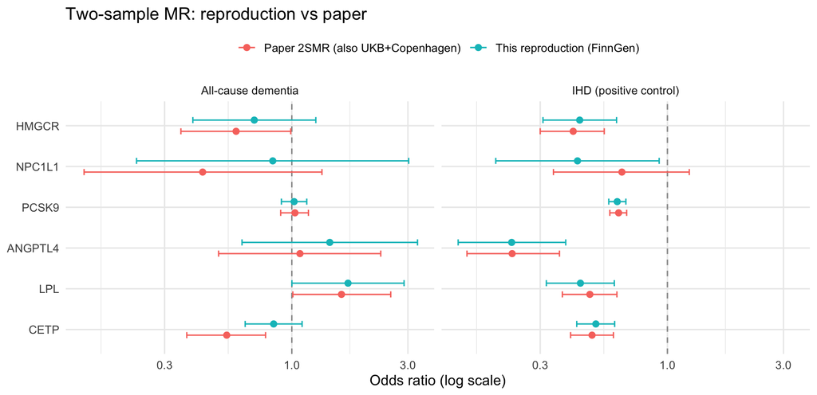

```r
paper2 <- rbindlist(list(
  data.table(outcome="dementia_all", gene=gene_order,
    or=c(0.59,0.43,1.03,1.08,1.60,0.54), lo=c(0.35,0.14,0.90,0.50,1.01,0.37), hi=c(0.99,1.33,1.17,2.32,2.55,0.78)),
  data.table(outcome="ihd", gene=gene_order,
    or=c(0.41,0.65,0.63,0.23,0.48,0.49), lo=c(0.30,0.34,0.58,0.15,0.37,0.40), hi=c(0.55,1.23,0.68,0.36,0.62,0.60))))
paper2[, series := "Paper 2SMR (also UKB+Copenhagen)"]
ours2 <- main[outcome %in% c("dementia_all","ihd"), .(outcome, gene, or, lo=or_lci, hi=or_uci)][, series := "This reproduction (FinnGen)"]
cmp <- rbind(paper2, ours2)[!is.na(or)]
cmp[, outcome := factor(OUT_LAB[outcome], levels = OUT_LAB[c("dementia_all","ihd")])]
forest(cmp, "Two-sample MR: reproduction vs paper", colour = "series", facet = "outcome")
```

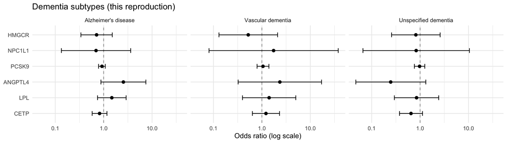

Our dementia-subtype estimates (FinnGen only; the paper reported subtypes in its Figure 4). Wide CIs reflect small case counts (~6k AD, ~2.7k vascular, ~4.4k unspecified).

```r
subd <- main[outcome %in% c("ad","vascular","unspecified") & !is.na(or), .(outcome, gene, or, lo=or_lci, hi=or_uci)]
subd[, outcome := factor(OUT_LAB[outcome], levels = OUT_LAB[c("ad","vascular","unspecified")])]
forest(subd, "Dementia subtypes (this reproduction)", facet = "outcome")
```

# 6 Robustness (Phase 2)

**Target-specific exposures.** Re-running each target on the trait it primarily acts on (LDL for the LDL-lowering targets, logTG for ANGPTL4/LPL) leaves directions unchanged; for the single-SNP Wald targets the *p-value is invariant* to the exposure trait (only the OR rescales).

**Estimator agreement (PCSK9, CETP).** All five estimators — IVW, weighted median, weighted mode, simple mode, MR-Egger — agree within rounding for both multi-SNP genes; MR-Egger is appropriately unstable at 3 SNPs (very wide CIs) and is shown for completeness rather than inference.

**Assumption checks.** Pleiotropy and heterogeneity are clean except a mild PCSK9→IHD Q signal:

```r
if (nrow(diag)) show(diag, c("gene","outcome","n_snp","egger_intercept","egger_intercept_p","Q","Q_pval"),
  "MR-Egger intercept ≈ 0 (P>0.05) → little directional pleiotropy; Cochran's Q P>0.05 → no excess heterogeneity")
```

MR-Egger intercept ≈ 0 (P>0.05) → little directional pleiotropy; Cochran’s Q P>0.05 → no excess heterogeneity

| gene | outcome | n_snp | egger_intercept | egger_intercept_p | Q | Q_pval |
| --- | --- | --- | --- | --- | --- | --- |
| PCSK9 | dementia_all | 3 | 0.0001 | 0.9943 | 0.1989 | 0.9053 |
| PCSK9 | ad | 3 | -0.0001 | 0.9975 | 1.9034 | 0.3861 |
| PCSK9 | vascular | 3 | 0.0339 | 0.4145 | 1.7581 | 0.4152 |
| PCSK9 | unspecified | 3 | 0.0186 | 0.6317 | 2.5544 | 0.2788 |
| PCSK9 | ihd | 3 | 0.0060 | 0.7812 | 7.4399 | 0.0242 |
| CETP | dementia_all | 3 | -0.0205 | 0.7984 | 0.1087 | 0.9471 |
| CETP | ad | 3 | -0.0046 | 0.9633 | 0.0043 | 0.9979 |
| CETP | vascular | 3 | 0.0083 | 0.9644 | 0.0033 | 0.9984 |
| CETP | unspecified | 3 | -0.0909 | 0.5969 | 0.5389 | 0.7638 |
| CETP | ihd | 3 | -0.0517 | 0.4010 | 1.8831 | 0.3900 |

**De-novo instrument selection.** Replacing the hardcoded rsIDs with the paper’s *method* (cis window → GWAS-significant → LD-clump r²≤0.05 on a local 1000G EUR panel → F>10): every paper-named SNP is a genuine GWAS-significant cis variant (`named_sig` = `named_n` for all six); some survive as clump leads, others are absorbed into a stronger-lead clump. The de-novo MR agrees in direction with the curated instruments, and IHD stays protective.

```r
if (nrow(dn)) show(dn, c("gene","n_cand","n_clumped","named_n","named_sig","named_lead","note"),
                   "De-novo selection vs the paper's named instruments")
```

De-novo selection vs the paper’s named instruments

| gene | n_cand | n_clumped | named_n | named_sig | named_lead | note |
| --- | --- | --- | --- | --- | --- | --- |
| HMGCR | 404 | 15 | 1 | 1 | 0 | named SNP(s) GWAS-sig but absorbed into a clump (not lead) |
| NPC1L1 | 364 | 4 | 1 | 1 | 0 | named SNP(s) GWAS-sig but absorbed into a clump (not lead) |
| PCSK9 | 387 | 17 | 3 | 3 | 1 | named as clump lead: rs11591147 |
| ANGPTL4 | 28 | 2 | 1 | 1 | 1 | named as clump lead: rs116843064 |
| LPL | 588 | 8 | 1 | 1 | 0 | named SNP(s) GWAS-sig but absorbed into a clump (not lead) |
| CETP | 166 | 8 | 3 | 3 | 1 | named as clump lead: rs3764261 |

# 7 Extension: bigger AD GWAS via OpenGWAS (NOT reproduction)

> **⚠** Bellenguez 2022 and Kunkle 2019 were **not** used by the original authors. This asks a *different, stronger* question — does the GLGC→AD signal hold in larger, independent AD GWAS? — and is reported separately from the reproduction.

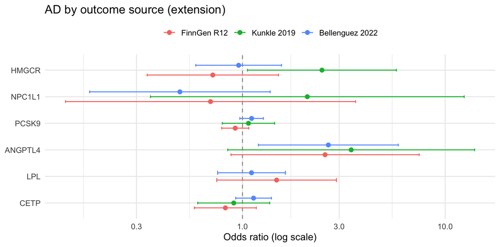

```r
adp <- ad[!is.na(or), .(gene, series = source, or, lo = or_lci, hi = or_uci)]
adp[, series := factor(series, levels = c("FinnGen R12","Kunkle 2019","Bellenguez 2022"))]
forest(adp, "AD by outcome source (extension)", colour = "series")
```

```r
if (nrow(meta)) show(orci(meta), c("gene","k_sources","OR (95% CI)","pval","Q_pval","sources"),
  "Meta-analysis: FinnGen + Bellenguez (fixed-effect). Kunkle NOT pooled — Bellenguez already contains the Kunkle/IGAP samples.")
```

Meta-analysis: FinnGen + Bellenguez (fixed-effect). Kunkle NOT pooled — Bellenguez already contains the Kunkle/IGAP samples.

| gene | k_sources | OR (95% CI) | pval | Q_pval | sources |
| --- | --- | --- | --- | --- | --- |
| HMGCR | 2 | 0.88 (0.58–1.32) | 0.5282877 | 0.5183478 | FinnGen R12 + Bellenguez 2022 |
| NPC1L1 | 2 | 0.54 (0.23–1.29) | 0.1669594 | 0.7250523 | FinnGen R12 + Bellenguez 2022 |
| PCSK9 | 2 | 1.02 (0.93–1.13) | 0.6480155 | 0.0738808 | FinnGen R12 + Bellenguez 2022 |
| ANGPTL4 | 2 | 2.62 (1.38–4.95) | 0.0031010 | 0.9564912 | FinnGen R12 + Bellenguez 2022 |
| LPL | 2 | 1.19 (0.85–1.66) | 0.3142522 | 0.4745000 | FinnGen R12 + Bellenguez 2022 |
| CETP | 2 | 1.05 (0.88–1.25) | 0.6100468 | 0.1222023 | FinnGen R12 + Bellenguez 2022 |

Adding cases sharpened the AD arm: the null targets became *confident* nulls (PCSK9 meta 1.02 (0.93–1.13)), and **ANGPTL4** crossed into significance (harmful direction, consistent across all three GWAS). But ANGPTL4 remains single-instrument, so precision — not validity — is what improved; its OR is also scale-sensitive. Treat it as a lead for a multi-instrument follow-up, not a finding.

**Where the sources disagree, there are concrete reasons — it is not random noise between equals.** The sharpest example is **HMGCR**: protective/null in FinnGen (0.71) and Bellenguez (0.96) but significantly *harmful* in Kunkle (2.47, p=0.04). Two structural explanations, not biology:

1. **Single-instrument fragility.** HMGCR, NPC1L1, ANGPTL4 and LPL each rest on *one* variant (a Wald ratio), so a cohort’s estimate is entirely that SNP’s association with AD in that dataset — there is no averaging to damp sampling noise, and a single-SNP estimate can flip sign between cohorts by chance. The multi-SNP genes (PCSK9, CETP) are correspondingly stable across all three sources. So a lone-SNP flip like HMGCR-in-Kunkle is expected imprecision, not a real contradiction.
2. **Different AD phenotypes.** FinnGen is registry-diagnosed (Finnish ICD codes); Kunkle is clinically-adjudicated case–control; **Bellenguez adds by-proxy cases** (UK Biobank participants labelled by *family history*, not their own diagnosis). Proxy-AD is a noisier, diluted phenotype, so systematic gaps between Bellenguez and FinnGen partly reflect *what “AD” means* in each study, not just sample size. This is also why we lean on the FinnGen+Bellenguez **meta** (whose Cochran’s Q shows no significant disagreement) rather than any single source.

# 8 Why we did not reproduce the one-sample arm

One-sample MR needs **individual-level** data — every participant’s genotype *and* lipids *and* dementia status in one dataset — which exists only in Copenhagen (CCHS+CGPS; Danish law forbids public sharing) and UK Biobank (application required). Public **summary statistics** give only per-variant β/SE, which support two-sample MR but not one-sample. So the one-sample arm is permanently out of reach here; the paper’s published one-sample results are the headline figure at the top of this report.

That arm is where the paper’s dementia conclusions are strongest — HMGCR, NPC1L1, and CETP are clearly protective with tight intervals — because ~500k individuals and a per-mmol/L contrast give far more power than our single FinnGen summary dataset. Our two-sample arm reproduces the *direction* of these, and matches the well-powered IHD control closely, but cannot on its own deliver the same dementia significance.

# 9 Documented deviations from the paper